# GWAS-by-subtraction - AN conditioned on BMI

Karanvir Singh

2023-03-19

# Results

## Genomic SEM (GWAS-by-subtraction)

Using summary statistics from the 2019 AN GWAS (Watson et. al) and 2018 BMI GWAS (Yengo et. al). BMI GWAS sumstats are imputed against 1KG EUR reference panel by me using RAISS. There are **3,255,926** SNPs for which I have both marginal and conditional effect sizes (a subset of the 7,328,751 AN SNPs and 3,909,793 BMI-imputed SNPs).

After merging the sumstats, I have:

1. 117 genome-wide significant SNPs in AN sumstats
2. 75,913 genome-wide significant SNPs in BMI sumstats
3. 104 genome-wide significant SNPs after conditioning on BMI

### Change in effect sizes

All 104 SNPs that reach genome-wide significance in the conditioned results are also genome-wide significant in the anorexia sumstats.

The forestplot here shows the marginal and conditional effect sizes for the 117 AN GWS SNPs.

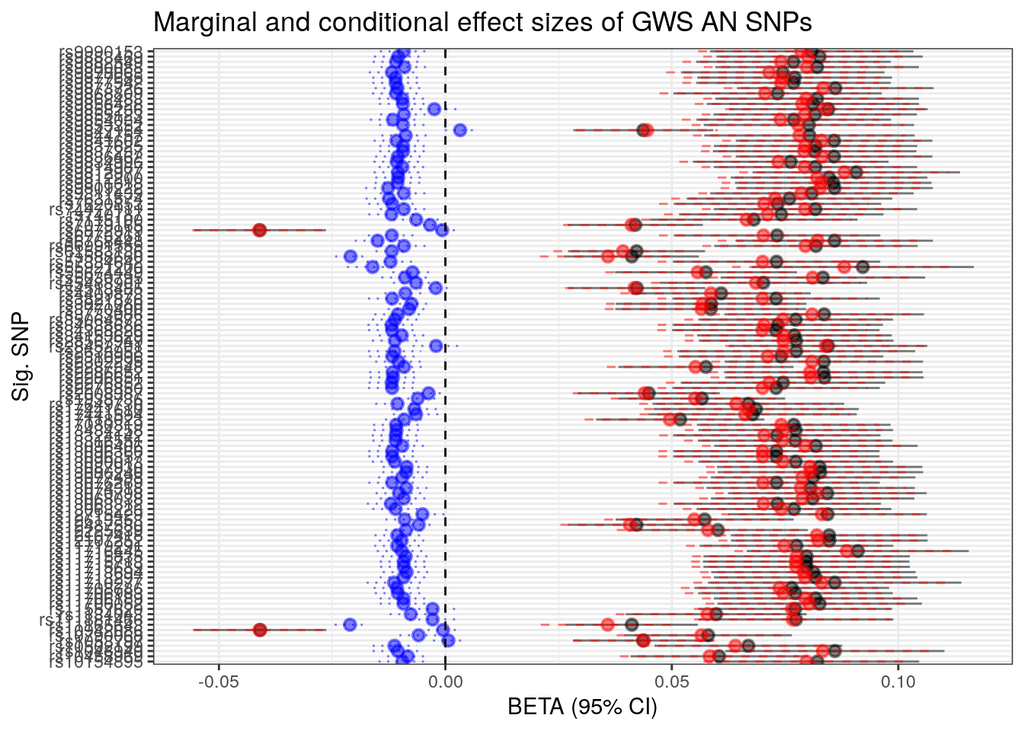

```r
# Am I comparing the effect sizes to the wrong reference? The sumstats function in genomicSEM scales the betas relative to unit-variance scaled phenotypes

p_sumstats_imp %>% mutate(AN_LOWER = beta.AN - 1.96*se.AN,
         AN_HIGHER = beta.AN + 1.96*se.AN,
         CON_LOWER = BETA.con - 1.96*SE.con,
         CON_HIGHER = BETA.con + 1.96*SE.con,
         BMI_HIGHER = beta.BMI + 1.96*se.BMI,
         BMI_LOWER = beta.BMI - 1.96*se.BMI) %>%
  filter(P.AN < 5e-8) %>%
  ggplot(data=., ) +
        geom_pointrange(aes(x=SNP, y=beta.AN, ymin=AN_LOWER, ymax=AN_HIGHER), alpha=0.5) +
  geom_pointrange(aes(x=SNP, y=BETA.con, ymin=CON_LOWER, ymax=CON_HIGHER), lty=2, alpha=0.5, col="red")+
  geom_pointrange(aes(x=SNP, y=beta.BMI, ymin=BMI_LOWER, ymax=BMI_HIGHER), lty=3, alpha=0.5, col="blue")+
        geom_hline(yintercept=0, lty=2) +  # add a dotted line at x=0 after flip
        coord_flip() +  # flip coordinates (puts labels on y axis)
        xlab("Sig. SNP") + ylab("BETA (95% CI)") +
  ggtitle("Marginal and conditional effect sizes of GWS AN SNPs")+
        theme_bw()  # use a white background
```

### FUMA lead SNPs and independent significant SNPs

The original AN GWAS identified 8 risk loci and 8 lead SNPs. Here, I am trying to determine which SNPs in my results tags each of the lead SNPs so that I can focus my analysis on those set of independent, significant SNPs.

This table shows the lead SNPs as identified in the original GWAS.

```r
watsonLeads <- c("rs10747478",
"rs2287348",
"rs9821797",
"rs9874207",
"rs13100344",
"rs370838138",
"rs2008387",
"rs6589488")

an_sumstats %>% filter(SNP %in% watsonLeads) %>%
    mutate(P = format.pval(P, digits=5)) %>%
    kableExtra::kbl() %>%
  kable_paper("hover", full_width = T)
```

| SNP | CHR | BP | A2 | A1 | BETA | SE | P | NGT | IMPINFO | NEFFDIV2 | NCAS | NCON | DIRE |
| --- | --- | --- | --- | --- | --- | --- | --- | --- | --- | --- | --- | --- | --- |
| rs10747478 | 1 | 96901455 | T | G | -0.0757010 | 0.0137 | 3.133e-08 | 0 | 0.969 | 23160.95 | 16992 | 55525 | +++-+++-++++++–++++++++++-+-+-++ |
| rs2287348 | 2 | 54039813 | C | T | 0.1044054 | 0.0179 | 5.619e-09 | 7 | 0.995 | 23160.95 | 16992 | 55525 | +++++-+-+++-+++++–+++-++++++++– |
| rs9821797 | 3 | 48718253 | T | A | 0.1565953 | 0.0201 | 6.987e-15 | 0 | 0.968 | 23160.95 | 16992 | 55525 | ++-++-+++++++++++–+++++++++++-+- |
| rs9874207 | 3 | 71019750 | T | C | 0.0812968 | 0.0145 | 2.048e-08 | 1 | 0.845 | 23160.95 | 16992 | 55525 | –++——-+-+–+–+++++-+—-++- |
| rs13100344 | 3 | 94605107 | T | A | -0.0745971 | 0.0136 | 4.209e-08 | 0 | 0.965 | 23160.95 | 16992 | 55525 | —————++++–+++–+—— |
| rs370838138 | 5 | 25081845 | G | C | -0.0753023 | 0.0136 | 3.173e-08 | 0 | 0.985 | 23160.95 | 16992 | 55525 | ———+—+-+-+——+++—— |
| rs2008387 | 10 | 131448764 | G | A | 0.0815029 | 0.0145 | 1.725e-08 | 0 | 0.940 | 23160.95 | 16992 | 55525 | +++++-+-+++++-+-++++++++++–++++- |
| rs6589488 | 11 | 115096956 | A | T | -0.1273020 | 0.0195 | 6.305e-11 | 0 | 0.946 | 23160.95 | 16992 | 55525 | ++-++-++++++++-++-++–++-+++++++- |

I use plink to calculate pairwise r^2 between the watson lead SNPs and all SNPs in a 3MB window around them, to identify which of the lead SNPs in the subset of data tag the lead SNPs in the original data.

```bash
plink --bfile EUR_phase3_autosomes --r2 --ld-snp-list watsonleads.txt  --ld-window-kb 3000 --ld-window 99999 --ld-window-r2 0
```

```r
leadLD <- read.table("plink.ld", header=TRUE)
subset_LD <- leadLD %>% filter(SNP_B %in% p_sumstats_imp$SNP) %>%
  left_join(., p_sumstats_imp %>% select(SNP, P.AN), by=c("SNP_B"="SNP"))

tagSNPs <- subset_LD %>% group_by(SNP_A) %>% slice_min(order_by = P.AN, with_ties = FALSE)

tagSNPs %>% select(-P.AN) %>%  kbl() %>% kable_paper("hover", full_width=T)
```

| CHR_A | BP_A | SNP_A | CHR_B | BP_B | SNP_B | R2 |
| --- | --- | --- | --- | --- | --- | --- |
| 1 | 96901455 | rs10747478 | 1 | 96924097 | rs11165643 | 0.995698 |
| 3 | 94605107 | rs13100344 | 3 | 94593959 | rs7619675 | 0.858930 |
| 10 | 131448764 | rs2008387 | 10 | 131448764 | rs2008387 | 1.000000 |
| 2 | 54039813 | rs2287348 | 2 | 54039813 | rs2287348 | 1.000000 |
| 5 | 25081845 | rs370838138 | 5 | 25086440 | rs6872919 | 0.978743 |
| 11 | 115096956 | rs6589488 | 11 | 115120615 | rs10502199 | 0.761969 |
| 3 | 48718253 | rs9821797 | 3 | 48712367 | rs9873726 | 1.000000 |
| 3 | 71019750 | rs9874207 | 3 | 70994006 | rs9847154 | 0.539007 |

A subset of the forestplot from above, which only shows the lead SNPs effect size changes.

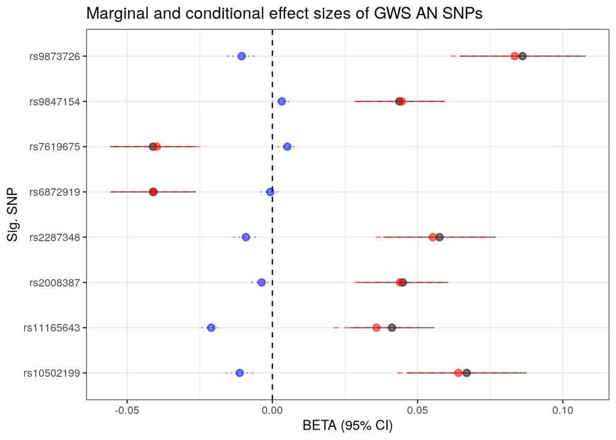

```r
# Foresplot of AN lead SNPs with original and conditioned effect sizes
p_sumstats_imp %>% mutate(AN_LOWER = beta.AN - 1.96*se.AN,
         AN_HIGHER = beta.AN + 1.96*se.AN,
         CON_LOWER = BETA.con - 1.96*SE.con,
         CON_HIGHER = BETA.con + 1.96*SE.con,
         BMI_HIGHER = beta.BMI + 1.96*se.BMI,
         BMI_LOWER = beta.BMI - 1.96*se.BMI) %>%
  filter(SNP %in% tagSNPs$SNP_B) %>%
  ggplot(data=., ) +
        geom_pointrange(aes(x=SNP, y=beta.AN, ymin=AN_LOWER, ymax=AN_HIGHER), alpha=0.5) +
  geom_pointrange(aes(x=SNP, y=BETA.con, ymin=CON_LOWER, ymax=CON_HIGHER), lty=2, alpha=0.5, col="red")+
  geom_pointrange(aes(x=SNP, y=beta.BMI, ymin=BMI_LOWER, ymax=BMI_HIGHER), lty=3, alpha=0.5, col="blue")+
        geom_hline(yintercept=0, lty=2) +  # add a dotted line at x=0 after flip
        coord_flip() +  # flip coordinates (puts labels on y axis)
        xlab("Sig. SNP") + ylab("BETA (95% CI)") +
  ggtitle("Marginal and conditional effect sizes of GWS AN SNPs")+
        theme_bw()  # use a white background
```

The following table shows the conditional and marginal effect sizes for the 8 Watson lead SNPs, and P-values.

```r
imputed_tagSNPs_betas <- tagSNPs %>% select(SNP_A, SNP_B, CHR_B, R2) %>% left_join(p_sumstats_imp %>% select(SNP, beta.AN, P.AN, BETA.con, P.con),
                      by=c("SNP_B"="SNP")) %>% arrange(CHR_B)

imputed_tagSNPs_betas %>%
  mutate(P.AN = format.pval(P.AN, digits=5),
         P.con = format.pval(P.con, digits=5)) %>%
  kbl() %>%
  kable_paper("hover")
```

| SNP_A | SNP_B | CHR_B | R2 | beta.AN | P.AN | BETA.con | P.con |
| --- | --- | --- | --- | --- | --- | --- | --- |
| rs10747478 | rs11165643 | 1 | 0.995698 | 0.0411669 | 3.465e-08 | 0.0358512 | 2.0682e-06 |
| rs2287348 | rs2287348 | 2 | 1.000000 | 0.0575318 | 5.619e-09 | 0.0552194 | 3.1823e-08 |
| rs13100344 | rs7619675 | 3 | 0.858930 | -0.0411103 | 5.225e-08 | -0.0398015 | 1.9014e-07 |
| rs9821797 | rs9873726 | 3 | 1.000000 | 0.0861034 | 7.881e-15 | 0.0834259 | 9.9343e-14 |
| rs9874207 | rs9847154 | 3 | 0.539007 | 0.0437017 | 2.747e-08 | 0.0445344 | 2.3373e-08 |
| rs370838138 | rs6872919 | 5 | 0.978743 | -0.0409488 | 4.053e-08 | -0.0411304 | 4.6872e-08 |
| rs2008387 | rs2008387 | 10 | 1.000000 | 0.0449144 | 1.725e-08 | 0.0439739 | 5.3834e-08 |
| rs6589488 | rs10502199 | 11 | 0.761969 | 0.0668946 | 2.7e-10 | 0.0640449 | 2.2458e-09 |

### Non-imputed BMI SNPs

Just to make sure the additional imputation step using RAISS (to increase the number of SNPs in the intersection of the two GWASs), I also fit the model using the not-imputed BMI sumstats. There are now 1,877,083 SNPs for which I have marginal and conditional effect sizes.

68 GWS AN SNPs 59 GWS AN-conditioned-on-BMI SNPs.

```r
# load p_sumstats
load("/home/karan099/scratch/scripts/gwas-by-subtraction/AN-minus-BMI-not-imputed/Sumstats.RData")

# load conditioned results
conditionedAN_notIMP <- vroom::vroom("/home/karan099/scratch/scripts/gwas-by-subtraction/AN-minus-BMI-not-imputed/an-conditioned-bmi-not-imputed-google-model.tsv")

# change column names
conditionedAN_notIMP <- conditionedAN_notIMP %>% rename(BETA.con = "BETA",
                          P.con = "P",
                          SE.con = "SE")

#load not imputed bmi sumstats
bmi_not_imp <- vroom::vroom("/home/karan099/project/ksingh/data/summary_stats/Munged/BMI_2018.tsv.gz")

# Merge p_sumstats with conditioned betas, se and p
p_sumstats_not_imp <- left_join(p_sumstats, conditionedAN_notIMP %>% select(SNP, BETA.con, P.con, SE.con))

# Add anorexia and BMI p values to p sumstats
p_sumstats_not_imp <- left_join(p_sumstats_not_imp, an_sumstats %>% select(SNP, P), by="SNP") %>%
  left_join(., bmi_not_imp %>% select(SNP, P), by="SNP", suffix=c(".AN", ".BMI"))


# How many genome-wide significant hits in the merged sumstats?
# nrow(p_sumstats_not_imp %>% filter(P.con < 5e-8)) # 59
# nrow(p_sumstats_not_imp %>% filter(P.AN < 5e-8)) # 68
# nrow(p_sumstats_not_imp %>% filter(P.BMI < 5e-8)) # 34,168

# Are all conditional significant SNPs also marginally significant SNPs? yes
# nrow(p_sumstats_not_imp %>% filter(P.con < 5e-8 & P.AN > 5e-8))
```

Like above, I am seeing which SNP in the subset of SNPs I am using tags the lead SNPs identified by Watson et. al. I have a tag SNP for each of the 8 lead SNPs.

```r
whichSNP_notIMP <- leadLD %>% filter(SNP_B %in% p_sumstats_not_imp$SNP)
whichSNP_notIMP <- whichSNP_notIMP %>% left_join(., p_sumstats_not_imp %>% select(SNP, P.AN), by=c("SNP_B"="SNP"))

tagSNPs_notIMP <- whichSNP_notIMP %>% group_by(SNP_A) %>% slice_min(order_by = P.AN, with_ties = FALSE)

tagSNPs_notIMP %>% select(-P.AN) %>% kbl() %>% kable_paper("hover", full_width=T)
```

| CHR_A | BP_A | SNP_A | CHR_B | BP_B | SNP_B | R2 |
| --- | --- | --- | --- | --- | --- | --- |
| 1 | 96901455 | rs10747478 | 1 | 96924097 | rs11165643 | 0.995698 |
| 3 | 94605107 | rs13100344 | 3 | 94593959 | rs7619675 | 0.858930 |
| 10 | 131448764 | rs2008387 | 10 | 131448764 | rs2008387 | 1.000000 |
| 2 | 54039813 | rs2287348 | 2 | 54039813 | rs2287348 | 1.000000 |
| 5 | 25081845 | rs370838138 | 5 | 25086440 | rs6872919 | 0.978743 |
| 11 | 115096956 | rs6589488 | 11 | 115120615 | rs10502199 | 0.761969 |
| 3 | 48718253 | rs9821797 | 3 | 48712367 | rs9873726 | 1.000000 |
| 3 | 71019750 | rs9874207 | 3 | 70994006 | rs9847154 | 0.539007 |

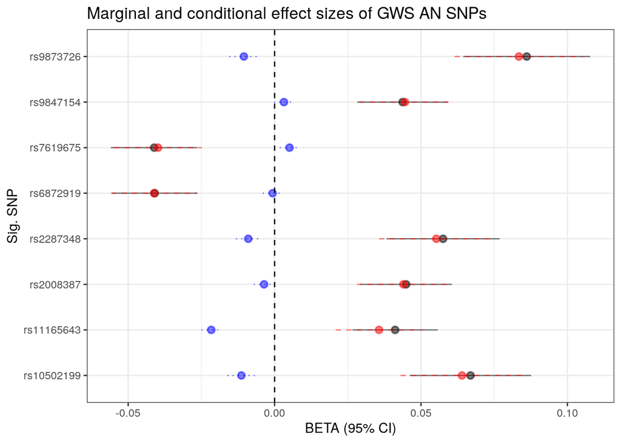

```r
# Foresplot of AN lead SNPs with original and conditioned effect sizes
p_sumstats_not_imp %>% mutate(AN_LOWER = beta.AN - 1.96*se.AN,
         AN_HIGHER = beta.AN + 1.96*se.AN,
         CON_LOWER = BETA.con - 1.96*SE.con,
         CON_HIGHER = BETA.con + 1.96*SE.con,
         BMI_HIGHER = beta.BMI + 1.96*se.BMI,
         BMI_LOWER = beta.BMI - 1.96*se.BMI) %>%
  filter(SNP %in% tagSNPs_notIMP$SNP_B) %>%
  ggplot(data=., ) +
        geom_pointrange(aes(x=SNP, y=beta.AN, ymin=AN_LOWER, ymax=AN_HIGHER), alpha=0.5) +
  geom_pointrange(aes(x=SNP, y=BETA.con, ymin=CON_LOWER, ymax=CON_HIGHER), lty=2, alpha=0.5, col="red")+
  geom_pointrange(aes(x=SNP, y=beta.BMI, ymin=BMI_LOWER, ymax=BMI_HIGHER), lty=3, alpha=0.5, col="blue")+
        geom_hline(yintercept=0, lty=2) +  # add a dotted line at x=0 after flip
        coord_flip() +  # flip coordinates (puts labels on y axis)
        xlab("Sig. SNP") + ylab("BETA (95% CI)") +
  ggtitle("Marginal and conditional effect sizes of GWS AN SNPs")+
        theme_bw()  # use a white background
```

The following table shows the effect sizes for each tag SNP as calculated through the model fitted on either the imputed BMI sumstats, or the non-imputed (original) sumstats. The tag SNP in each case is identical, and the results show that the additional imputing step does not change the conditioned betas or P-values of the tag SNPs. In both cases, the SNPs tagging lead SNPs rs10747478, rs13100344 and rs2008387 are not significant at the genome-wide significance level after conditioning on BMI.

To note, I do not have a GWS tag SNP for lead SNP rs13100344. Additionally, SNP rs2008387 although not significant is still borderline genome-wide significant (p=1.725e-08, p_con = 5.2961e-08)

```r
not_imputed_tagSNPs_betas <- tagSNPs_notIMP %>% select(SNP_A, SNP_B, CHR_B, R2) %>% left_join(p_sumstats_not_imp %>% select(SNP, beta.AN, P.AN, BETA.con, P.con),
                      by=c("SNP_B"="SNP")) %>% arrange(CHR_B)

imputed_versus_not_imputed_sem <- left_join(imputed_tagSNPs_betas, not_imputed_tagSNPs_betas, by="SNP_A") %>%
  select(SNP_A, SNP_B.x, SNP_B.y, R2.x, R2.y, beta.AN.x, beta.AN.y, BETA.con.x, BETA.con.y, P.AN.x, P.AN.y, P.con.x, P.con.y)

imputed_versus_not_imputed_sem %>%
  select(SNP_A, ends_with(".x"), ends_with(".y")) %>%
  mutate(across(starts_with("P"), ~format.pval(.x, digits=5))) %>%
  kbl(col.names = c("SNP", "tag SNP", "R2", "beta (AN)", "beta (con)", "P(AN)", "P(con)",
                    "tag SNP", "R2", "beta (AN)", "beta (con)", "P(AN)", "P(con)")) %>%
  add_header_above(c(" " = 1, "Imputed" = 6, "Not Imputed" = 6)) %>%
  row_spec(c(2,4,5,6,8), bold =  TRUE) %>%
  column_spec(c(6,7,12,13), background="grey") %>%
  kable_paper()
```

| SNP | Imputed tag SNP | Imputed R2 | Imputed beta (AN) | Imputed beta (con) | Imputed P(AN) | Imputed P(con) | Not Imputed tag SNP | Not Imputed R2 | Not Imputed beta (AN) | Not Imputed beta (con) | Not Imputed P(AN) | Not Imputed P(con) |
| --- | --- | --- | --- | --- | --- | --- | --- | --- | --- | --- | --- | --- |
| rs10747478 | rs11165643 | 0.995698 | 0.0411669 | 0.0358512 | 3.465e-08 | 2.0682e-06 | rs11165643 | 0.995698 | 0.0411669 | 0.0356696 | 3.465e-08 | 2.343e-06 |
| rs2287348 | rs2287348 | 1.000000 | 0.0575318 | 0.0552194 | 5.619e-09 | 3.1823e-08 | rs2287348 | 1.000000 | 0.0575318 | 0.0552360 | 5.619e-09 | 3.1477e-08 |
| rs13100344 | rs7619675 | 0.858930 | -0.0411103 | -0.0398015 | 5.225e-08 | 1.9014e-07 | rs7619675 | 0.858930 | -0.0411103 | -0.0398068 | 5.225e-08 | 1.8919e-07 |
| rs9821797 | rs9873726 | 1.000000 | 0.0861034 | 0.0834259 | 7.881e-15 | 9.9343e-14 | rs9873726 | 1.000000 | 0.0861034 | 0.0834314 | 7.881e-15 | 9.8749e-14 |
| rs9874207 | rs9847154 | 0.539007 | 0.0437017 | 0.0445344 | 2.747e-08 | 2.3373e-08 | rs9847154 | 0.539007 | 0.0437017 | 0.0445204 | 2.747e-08 | 2.3571e-08 |
| rs370838138 | rs6872919 | 0.978743 | -0.0409488 | -0.0411304 | 4.053e-08 | 4.6872e-08 | rs6872919 | 0.978743 | -0.0409488 | -0.0411199 | 4.053e-08 | 4.717e-08 |
| rs2008387 | rs2008387 | 1.000000 | 0.0449144 | 0.0439739 | 1.725e-08 | 5.3834e-08 | rs2008387 | 1.000000 | 0.0449144 | 0.0439952 | 1.725e-08 | 5.2961e-08 |
| rs6589488 | rs10502199 | 0.761969 | 0.0668946 | 0.0640449 | 2.7e-10 | 2.2458e-09 | rs10502199 | 0.761969 | 0.0668946 | 0.0640015 | 2.7e-10 | 2.3004e-09 |

### Manhattan plots

**Imputed SNPs**

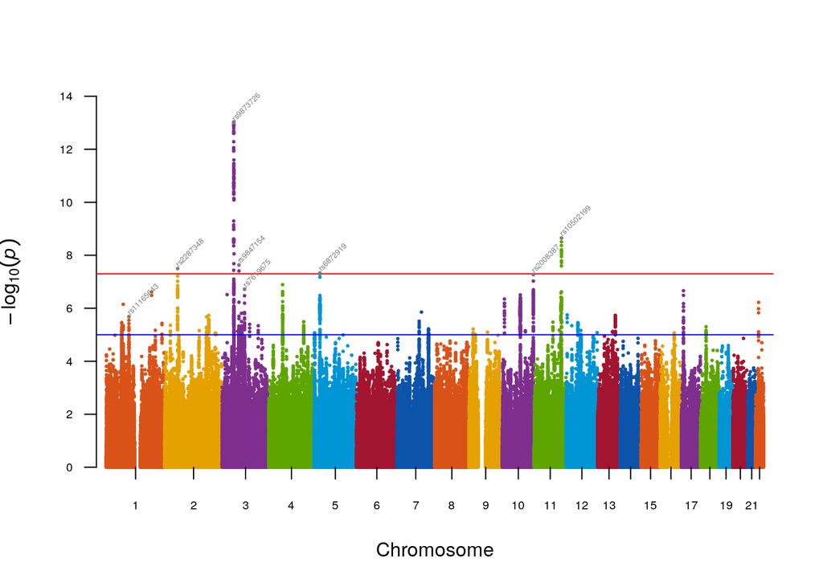

```r
fastman(p_sumstats_imp, p="P.con", highlight = imputed_tagSNPs_betas$SNP_B, annotateHighlight = TRUE, annotateTop = FALSE)
```

**Not imputed SNPs**

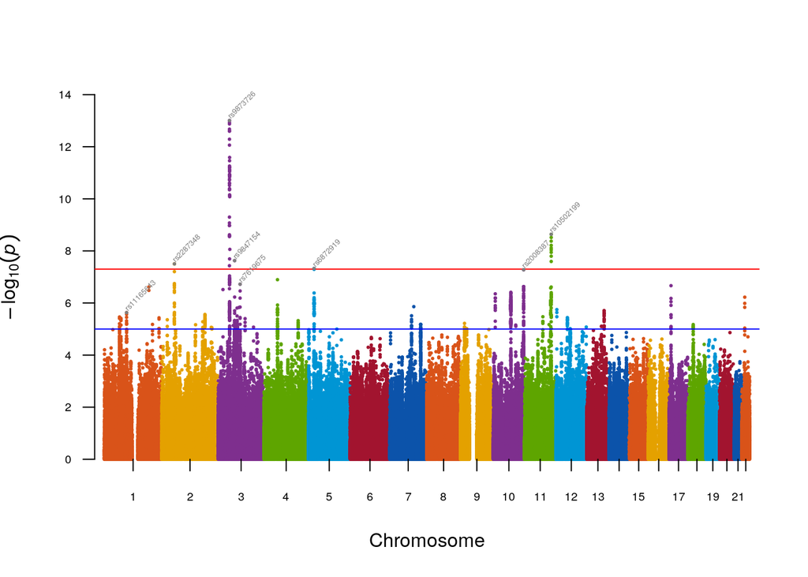

```r
fastman(p_sumstats_not_imp, p="P.con", highlight = imputed_tagSNPs_betas$SNP_B, annotateHighlight = TRUE, annotateTop = FALSE)
```

**AN**

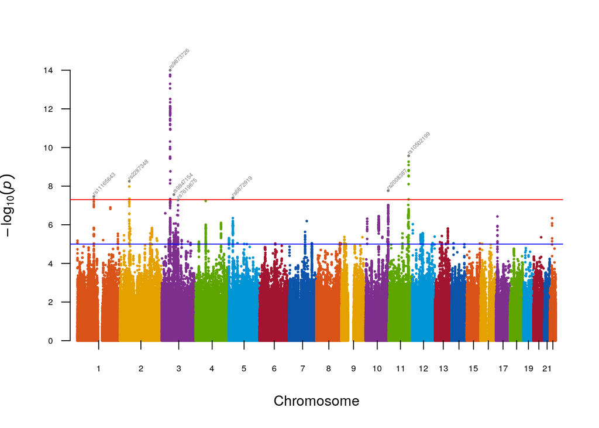

```r
fastman(p_sumstats_not_imp, p="P.AN", highlight = imputed_tagSNPs_betas$SNP_B, annotateHighlight = TRUE, annotateTop = FALSE)
```

## mtCOJO

I ran mtCOJO using the same subet of SNPs in both cases (imputed or not imputed).

When using the non-imputed SNPs (n = 1,877,083), I have 62 GWS SNPs after conditioning, and all 62 are also GWS before conditioning (out of 68).

```r
# imputed
cojo_imputed <- vroom::vroom("/home/karan099/scratch/scripts/mtCOJO/AN-minus-BMI-imputed/AN_minus_BMI_imp_.mtcojo.cma")


# not imputed
cojo_not_imp <- vroom::vroom("/home/karan099/scratch/scripts/mtCOJO/AN-minus-BMI-not-imputed/AN_minus_BMI_not_imp_mtcojo.cma")

nrow(cojo_not_imp %>% filter(bC_pval < 5e-8))
```

```
## [1] 62
```

```r
nrow(cojo_not_imp %>% filter(bC_pval < 5e-8 & p > 5e-8))
```

```
## [1] 0
```

```r
nrow(cojo_not_imp %>% filter(p < 5e-8))
```

```
## [1] 68
```

```r
# imputed
nrow(cojo_imputed %>% filter(bC_pval < 5e-8))
```

```
## [1] 109
```

```r
nrow(cojo_imputed %>% filter(bC_pval < 5e-8 & p > 5e-8))
```

```
## [1] 0
```

```r
nrow(cojo_imputed %>% filter(p < 5e-8))
```

```
## [1] 117
```

Table that shows the 8 SNPs that tag the 8 Watson lead SNPs, with mtCOJO betas and P values, as well as the corresponding effect sizes estimated from genomic SEM.

```r
cojo_not_imp_leads <- cojo_not_imp %>% select(SNP, b, p, bC, bC_pval) %>%
  right_join(tagSNPs_notIMP, by=c("SNP" = "SNP_B")) %>%
  select(CHR_A, SNP_A, SNP, R2, b, bC, p, bC_pval) %>%
  arrange(CHR_A)

cojo_not_imp_leads <- left_join(cojo_not_imp_leads, not_imputed_tagSNPs_betas %>% select(SNP_A, beta.AN, BETA.con, P.con), by=c("SNP_A"))

cojo_not_imp_leads <- cojo_not_imp_leads %>%
  mutate(p = format.pval(p, digits=5),
         bC_pval = format.pval(bC_pval, digits=5),
         P.con = format.pval(P.con, digits=5))

cojo_not_imp_leads$p <- cell_spec(cojo_not_imp_leads$p, color = ifelse(as.numeric(cojo_not_imp_leads$p) < 5e-8, "green", "red"))
cojo_not_imp_leads$bC_pval <- cell_spec(cojo_not_imp_leads$bC_pval, color = ifelse(as.numeric(cojo_not_imp_leads$bC_pval) < 5e-8, "green", "red"))
cojo_not_imp_leads$P.con <- cell_spec(cojo_not_imp_leads$P.con, color = ifelse(as.numeric(cojo_not_imp_leads$P.con) < 5e-8, "green", "red"))

cojo_not_imp_leads  %>%
  kbl(escape = FALSE) %>%
  add_header_above(c(" " = 4, "mtCOJO" = 4, "genomicSEM" = 3)) %>%  kable_paper("hover")
```

| CHR_A | SNP_A | SNP | R2 | mtCOJO b | mtCOJO bC | mtCOJO p | mtCOJO bC_pval | genomicSEM beta.AN | genomicSEM BETA.con | genomicSEM P.con |
| --- | --- | --- | --- | --- | --- | --- | --- | --- | --- | --- |
| 1 | rs10747478 | rs11165643 | 0.995698 | 0.0746992 | 0.0666593 | 3.465e-08 | 8.1445e-07 | 0.0411669 | 0.0356696 | 2.3430e-06 |
| 2 | rs2287348 | rs2287348 | 1.000000 | 0.1044050 | 0.1006200 | 5.619e-09 | 1.9739e-08 | 0.0575318 | 0.0552360 | 3.1477e-08 |
| 3 | rs13100344 | rs7619675 | 0.858930 | -0.0745971 | -0.0726067 | 5.225e-08 | 1.1989e-07 | -0.0411103 | -0.0398068 | 1.8919e-07 |
| 3 | rs9874207 | rs9847154 | 0.539007 | 0.0793030 | 0.0805519 | 2.747e-08 | 1.8331e-08 | 0.0437017 | 0.0445204 | 2.3571e-08 |
| 3 | rs9821797 | rs9873726 | 1.000000 | 0.1563030 | 0.1519710 | 7.881e-15 | 4.3348e-14 | 0.0861034 | 0.0834314 | 9.8749e-14 |
| 5 | rs370838138 | rs6872919 | 0.978743 | -0.0743034 | -0.0745766 | 4.053e-08 | 3.4357e-08 | -0.0409488 | -0.0411199 | 4.7170e-08 |
| 10 | rs2008387 | rs2008387 | 1.000000 | 0.0815029 | 0.0800589 | 1.725e-08 | 3.4889e-08 | 0.0449144 | 0.0439952 | 5.2961e-08 |
| 11 | rs6589488 | rs10502199 | 0.761969 | 0.1214000 | 0.1171060 | 2.700e-10 | 1.1139e-09 | 0.0668946 | 0.0640015 | 2.3004e-09 |

```r
cojo_imp_leads <- cojo_imputed %>% select(SNP, b, p, bC, bC_pval) %>%
  right_join(tagSNPs, by=c("SNP" = "SNP_B")) %>%
  select(CHR_A, SNP_A, SNP, R2, b, bC, p, bC_pval) %>%
  arrange(CHR_A)

cojo_imp_leads <- left_join(cojo_imp_leads, imputed_tagSNPs_betas %>% select(SNP_A, beta.AN, BETA.con, P.con), by=c("SNP_A"))

cojo_imp_leads <- cojo_imp_leads %>%
  mutate(p = format.pval(p, digits=5),
         bC_pval = format.pval(bC_pval, digits=5),
         P.con = format.pval(P.con, digits=5))

cojo_imp_leads$p <- cell_spec(cojo_imp_leads$p, color = ifelse(as.numeric(cojo_imp_leads$p) < 5e-8, "green", "red"))
cojo_imp_leads$bC_pval <- cell_spec(cojo_imp_leads$bC_pval, color = ifelse(as.numeric(cojo_imp_leads$bC_pval) < 5e-8, "green", "red"))
cojo_imp_leads$P.con <- cell_spec(cojo_imp_leads$P.con, color = ifelse(as.numeric(cojo_imp_leads$P.con) < 5e-8, "green", "red"))

cojo_imp_leads  %>%
  kbl(escape = FALSE) %>%
  add_header_above(c(" " = 4, "mtCOJO" = 4, "genomicSEM" = 3)) %>%  kable_paper("hover")
```

| CHR_A | SNP_A | SNP | R2 | mtCOJO b | mtCOJO bC | mtCOJO p | mtCOJO bC_pval | genomicSEM beta.AN | genomicSEM BETA.con | genomicSEM P.con |
| --- | --- | --- | --- | --- | --- | --- | --- | --- | --- | --- |
| 1 | rs10747478 | rs11165643 | 0.995698 | 0.0746992 | 0.0696802 | 3.465e-08 | 2.4855e-07 | 0.0411669 | 0.0358512 | 2.0682e-06 |
| 2 | rs2287348 | rs2287348 | 1.000000 | 0.1044050 | 0.1022300 | 5.619e-09 | 1.1396e-08 | 0.0575318 | 0.0552194 | 3.1823e-08 |
| 3 | rs13100344 | rs7619675 | 0.858930 | -0.0745971 | -0.0733672 | 5.225e-08 | 8.6703e-08 | -0.0411103 | -0.0398015 | 1.9014e-07 |
| 3 | rs9874207 | rs9847154 | 0.539007 | 0.0793030 | 0.0800830 | 2.747e-08 | 2.1737e-08 | 0.0437017 | 0.0445344 | 2.3373e-08 |
| 3 | rs9821797 | rs9873726 | 1.000000 | 0.1563030 | 0.1537830 | 7.881e-15 | 2.0587e-14 | 0.0861034 | 0.0834259 | 9.9343e-14 |
| 5 | rs370838138 | rs6872919 | 0.978743 | -0.0743034 | -0.0744737 | 4.053e-08 | 3.5140e-08 | -0.0409488 | -0.0411304 | 4.6872e-08 |
| 10 | rs2008387 | rs2008387 | 1.000000 | 0.0815029 | 0.0806195 | 1.725e-08 | 2.7407e-08 | 0.0449144 | 0.0439739 | 5.3834e-08 |
| 11 | rs6589488 | rs10502199 | 0.761969 | 0.1214000 | 0.1187180 | 2.700e-10 | 6.4088e-10 | 0.0668946 | 0.0640449 | 2.2458e-09 |